# Project2: SMARTPHONES PRICE PREDICTION

A first simple regression by a linear model:

```r
st_approach2 = lm(Price ~ Resolution.y, data = train_reg)
summary(st_approach2)
```

```
##
## Call:
## lm(formula = Price ~ Resolution.y, data = train_reg)
##
## Residuals:
##     Min      1Q  Median      3Q     Max
## -246.61  -50.56  -15.26   20.05 1675.10
##
## Coefficients:
##                Estimate Std. Error t value Pr(>|t|)
## (Intercept)  -99.788648  11.056164  -9.026   <2e-16 ***
## Resolution.y   0.152537   0.006966  21.897   <2e-16 ***
## ---
## Signif. codes:  0 '***' 0.001 '**' 0.01 '*' 0.05 '.' 0.1 ' ' 1
##
## Residual standard error: 126.7 on 1083 degrees of freedom
## Multiple R-squared:  0.3069, Adjusted R-squared:  0.3062
## F-statistic: 479.5 on 1 and 1083 DF,  p-value: < 2.2e-16
```

```r
cor(predict(st_approach2, newdata=test_reg),test_reg$Price)^2
```

```
## [1] 0.4226143
```

Graph analysis:

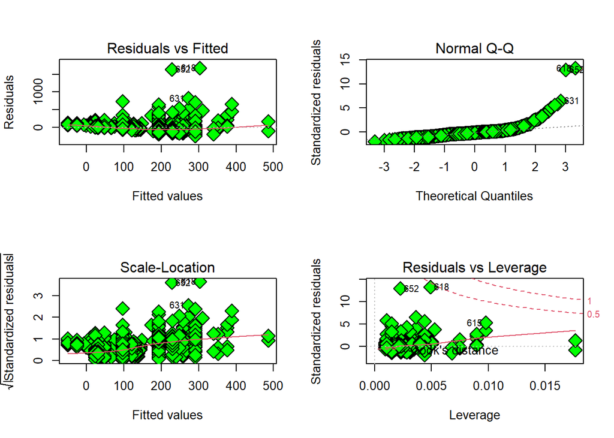

```r
par(mfrow=c(2,2))
plot(st_approach2, pch=23 ,bg='green',cex=2)
```

Will be better if we take the logarithm ?

```r
st_approach2_log = lm(Price ~ log(Resolution.y), data = train_reg)
summary(st_approach2_log)
```

```
##
## Call:
## lm(formula = Price ~ log(Resolution.y), data = train_reg)
##
## Residuals:
##     Min      1Q  Median      3Q     Max
## -201.65  -62.15  -25.09   17.63 1726.00
##
## Coefficients:
##                   Estimate Std. Error t value Pr(>|t|)
## (Intercept)       -1270.25      75.38  -16.85   <2e-16 ***
## log(Resolution.y)   193.18      10.41   18.56   <2e-16 ***
## ---
## Signif. codes:  0 '***' 0.001 '**' 0.01 '*' 0.05 '.' 0.1 ' ' 1
##
## Residual standard error: 132.6 on 1083 degrees of freedom
## Multiple R-squared:  0.2414, Adjusted R-squared:  0.2407
## F-statistic: 344.6 on 1 and 1083 DF,  p-value: < 2.2e-16
```

```r
cor(predict(st_approach2_log, newdata=test_reg),test_reg$Price)^2
```

```
## [1] 0.3377514
```

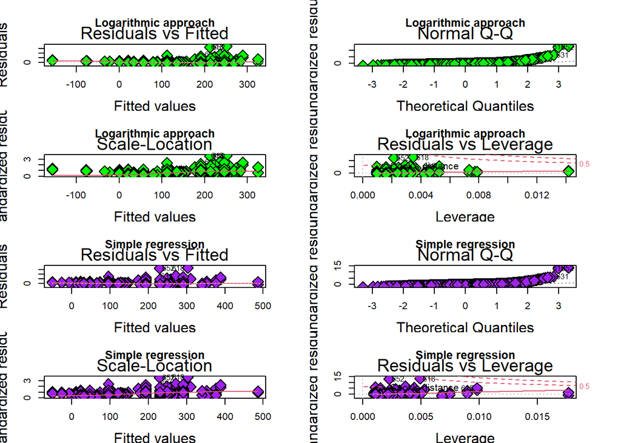

```r
par(mfrow=c(4,2), mai = c(.5,.5,.5,.5))
plot(st_approach2_log, pch=23 ,bg='green',cex=2,main = "Logarithmic approach",cex.caption = 1.2,cex.main = 1.2,cex.lab = 1.5,cex.lab = 1.5)
plot(st_approach2, pch=23 ,bg='purple',cex=2, main = "Simple regression",,cex.caption = 1.2,cex.main = 1.2,cex.lab = 1.5,cex.lab = 1.5)
```

In this case the logarithm just make it worse to analyse the Price variability.

Now, lets going to apply a second regression but in this case involving multiple variables. The variables introduced in this case will be a mix of factors and numeric, but that will not give problems since each level of the factors will be a new parameter for the linear model.

To estimate the coefficients, the goal is to minimize the sum of the squared errors between the predicted values of Y (using the regression equation) and the observed values of Y.

Not to say that the formula follows:

$$Y = b_0 + b_1*X_1 + b_2X_2 + ... +
b_n_Xn$$
Where bs are the coefficients computed by the linear model.

```r
mult_reg = lm(Price ~ Resolution.y + both_cameras + Wi.Fi+ Battery.capacity..mAh.+Operating.system , data = train_reg)
summary(mult_reg)
```

```
##
## Call:
## lm(formula = Price ~ Resolution.y + both_cameras + Wi.Fi + Battery.capacity..mAh. +
##     Operating.system, data = train_reg)
##
## Residuals:
##     Min      1Q  Median      3Q     Max
## -260.58  -47.26  -10.82   22.01 1691.71
##
## Coefficients:
##                              Estimate Std. Error t value Pr(>|t|)
## (Intercept)                -1.151e+02  5.189e+01  -2.217 0.026801 *
## Resolution.y                1.432e-01  9.523e-03  15.034  < 2e-16 ***
## both_cameras                7.326e-01  3.791e-01   1.932 0.053598 .
## Wi.FiYes                    2.536e+01  4.994e+01   0.508 0.611663
## Battery.capacity..mAh.     -5.493e-03  5.538e-03  -0.992 0.321458
## Operating.systemBlackBerry  8.444e+01  4.104e+01   2.058 0.039878 *
## Operating.systemCyanogen    3.841e+01  3.893e+01   0.987 0.323988
## Operating.systemiOS         2.852e+02  3.323e+01   8.581  < 2e-16 ***
## Operating.systemWindows     1.128e+02  3.296e+01   3.423 0.000643 ***
## ---
## Signif. codes:  0 '***' 0.001 '**' 0.01 '*' 0.05 '.' 0.1 ' ' 1
##
## Residual standard error: 121.9 on 1076 degrees of freedom
## Multiple R-squared:  0.3631, Adjusted R-squared:  0.3583
## F-statistic: 76.67 on 8 and 1076 DF,  p-value: < 2.2e-16
```

When testing with the test partition:

```r
cor(predict(mult_reg, newdata=test_reg),test_reg$Price)^2
```

```
## [1] 0.5121305
```

Now let’s get into deeper analysis:

## Selection of the best regression subset

```r
library(olsrr)
#model_fit = lm(Price ~ Resolution.y:Resolution.x + Rear.camera*Front.canera + X4g..LTE, Processor, Internal.storage..GB.*RAM..MB. +
#                Battery.Capacity..mAh, data = train_reg)

model_for_subsets = Price ~ Resolution.y:Resolution.x + Rear.camera*Front.camera + X4G..LTE + Processor + Internal.storage..GB.*RAM..MB. +
             Battery.capacity..mAh.

modelfit = lm(model_for_subsets, data = train_reg)

#to perform all the possible combinations:
ols_step_all_possible(modelfit)
```

```
##      Index  N
## 10       1  1
## 5        2  1
## 6        3  1
## 8        4  1
## 1        5  1
## 9        6  1
## 2        7  1
## 4        8  1
## 7        9  1
## 3       10  1
## 54      11  2
## 43      12  2
## 49      13  2
## 45      14  2
```

[output cut: 3057 more lines]

There are 1023 combinations with the features chosen.

So the best subsets for each criteria are:

```r
ols_step_best_subset(modelfit)
```

```
##                                                                                      Best Subsets Regression
## --------------------------------------------------------------------------------------------------------------------------------------------------------------------------------------------------
## Model Index    Predictors
## --------------------------------------------------------------------------------------------------------------------------------------------------------------------------------------------------
##      1         Internal.storage..GB.:RAM..MB.
##      2         Resolution.y:Resolution.x Internal.storage..GB.:RAM..MB.
##      3         Front.camera Resolution.y:Resolution.x Internal.storage..GB.:RAM..MB.
##      4         Front.camera Processor Resolution.y:Resolution.x Internal.storage..GB.:RAM..MB.
##      5         Front.camera Processor RAM..MB. Resolution.y:Resolution.x Internal.storage..GB.:RAM..MB.
##      6         Front.camera X4G..LTE Processor RAM..MB. Resolution.y:Resolution.x Internal.storage..GB.:RAM..MB.
##      7         Rear.camera Front.camera Processor RAM..MB. Resolution.y:Resolution.x Rear.camera:Front.camera Internal.storage..GB.:RAM..MB.
##      8         Rear.camera Front.camera Processor Internal.storage..GB. RAM..MB. Resolution.y:Resolution.x Rear.camera:Front.camera Internal.storage..GB.:RAM..MB.
##      9         Rear.camera Front.camera Processor Internal.storage..GB. RAM..MB. Battery.capacity..mAh. Resolution.y:Resolution.x Rear.camera:Front.camera Internal.storage..GB.:RAM..MB.
##     10         Rear.camera Front.camera X4G..LTE Processor Internal.storage..GB. RAM..MB. Battery.capacity..mAh. Resolution.y:Resolution.x Rear.camera:Front.camera Internal.storage..GB.:RAM..MB.
## --------------------------------------------------------------------------------------------------------------------------------------------------------------------------------------------------
##
##                                                             Subsets Regression Summary
## --------------------------------------------------------------------------------------------------------------------------------------------------
##                        Adj.        Pred
## Model    R-Square    R-Square    R-Square      C(p)         AIC          SBIC          SBC            MSEP            FPE          HSP       APC
## --------------------------------------------------------------------------------------------------------------------------------------------------
##   1        0.4417      0.4412      0.4272    267.0664    13355.3894    8046.0118    13370.3574    14032518.3132    12957.0366    11.9530    0.5603
##   2        0.5330      0.5322      0.5224     48.5943    13163.6249    6915.8603    13183.5822    11748401.8336    10857.9500    10.0167    0.4696
##   3        0.5478      0.5466      0.5349     14.8499    13130.6738    6743.7005    13155.6204    11386514.0302    10533.1543     9.7171    0.4555
##   4        0.5500      0.5483       0.536     11.7131    13127.5571    6792.6901    13157.4932    11343447.4567    10502.9420     9.6893    0.4542
##   5        0.5524      0.5503       0.538      7.9301    13123.7678    6837.1104    13158.6931    11293548.9185    10466.3251     9.6556    0.4526
##   6        0.5531      0.5506      0.5379      8.1033    13123.9326    6911.7241    13163.8473    11284931.5806    10467.9160     9.6572    0.4527
##   7        0.5537      0.5508      0.5281      8.6650    13124.4855    6989.4729    13169.3895    11280363.5708    10473.2518     9.6623    0.4529
##   8        0.5544      0.5511      0.5227      9.0066    13124.8145    7065.7860    13174.7079    11273481.8971    10476.4297     9.6653    0.4531
##   9        0.5549      0.5512      0.5218      9.8393    13125.6368    7145.9338    13180.5195    11271736.9674    10484.3739     9.6728    0.4534
##  10        0.5552      0.5511      0.5204     11.0000    13126.7892    7228.6407    13186.6613    11273432.1571    10495.5178     9.6833    0.4539
## --------------------------------------------------------------------------------------------------------------------------------------------------
## AIC: Akaike Information Criteria
##  SBIC: Sawa's Bayesian Information Criteria
##  SBC: Schwarz Bayesian Criteria
##  MSEP: Estimated error of prediction, assuming multivariate normality
##  FPE: Final Prediction Error
##  HSP: Hocking's Sp
##  APC: Amemiya Prediction Criteria
```

So now with forward based on the p-value got with each, let’s plot the influence of the steps:

```r
ols_step_forward_p(modelfit)
```

```
##
##                                          Selection Summary
## ----------------------------------------------------------------------------------------------------
##         Variable                                        Adj.
## Step               Entered                R-Square    R-Square      C(p)         AIC          RMSE
## ----------------------------------------------------------------------------------------------------
##    1    Internal.storage..GB.:RAM..MB.      0.4417      0.4412    267.0664    13355.3894    113.7242
##    2    X4G..LTE                            0.4449      0.4439    261.3124    13351.1305    113.4491
##    3    Battery.capacity..mAh.              0.4465      0.4450    259.4667    13350.0129    113.3386
##    4    Processor                           0.4496      0.4476    253.9517    13345.8947    113.0718
##    5    Front.camera                        0.4530      0.4504    247.8890    13341.2920    112.7805
##    6    Rear.camera                         0.4593      0.4563    234.6856    13330.7312    112.1816
##    7    Resolution.y:Resolution.x           0.5505      0.5476     16.3527    13132.1981    102.3267
##    8    Internal.storage..GB.               0.5513      0.5479     16.5137    13132.3580    102.2875
##    9    RAM..MB.                            0.5540      0.5503     11.8844    13127.6993    102.0215
##   10    Rear.camera:Front.camera            0.5552      0.5511     11.0000    13126.7892    101.9322
## ----------------------------------------------------------------------------------------------------
```

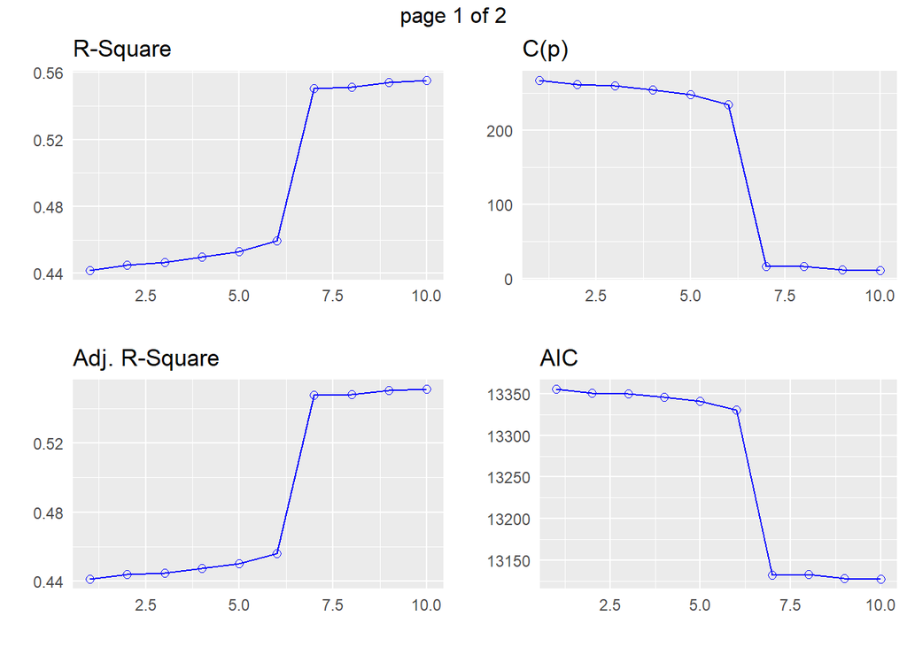

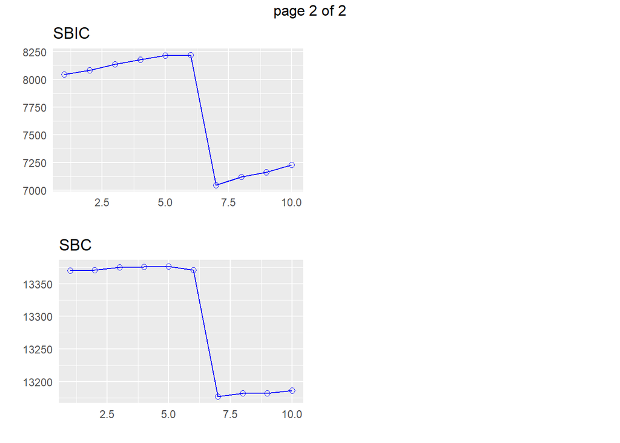

```r
plot(ols_step_forward_p(modelfit))
```

It can be observed how the steps affect to the increase of the $R^2$, specially in step, 6 to 7 that is taken by the resolution combination that indeed it has been proved that is one of the most important features to predict values.

Now let’s see the evolution with the removal of some variables affecting the model:

```r
ols_step_backward_p(modelfit)
```

```
##
##
##                               Elimination Summary
## --------------------------------------------------------------------------------
##         Variable                     Adj.
## Step      Removed      R-Square    R-Square     C(p)         AIC          RMSE
## --------------------------------------------------------------------------------
##    1    Rear.camera      0.5546      0.5508    10.6280    13126.4327    101.9620
## --------------------------------------------------------------------------------
```

[output not shown]

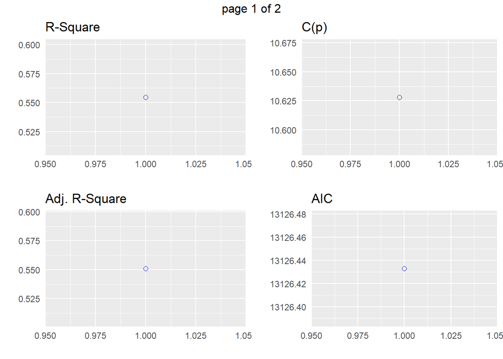

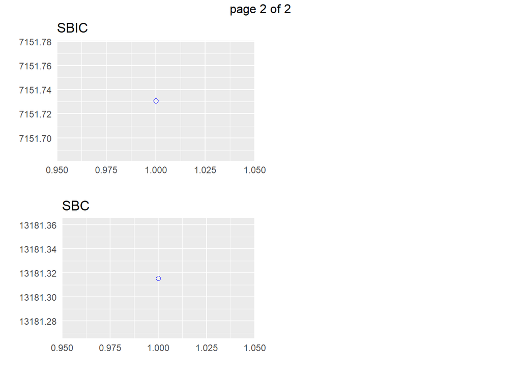

```r
plot(ols_step_backward_p(modelfit))
```

Now let see the same methods but focused on Akaike information Criterion

AIC is calculated by the number of independent variables usedd to build the model joined with the MLE of the model so tries to reach the explanation of the greatest amount of variation with the less variables possible:

```r
ols_step_forward_aic(modelfit)
```

```
##
##                                          Selection Summary
## ---------------------------------------------------------------------------------------------------
## Variable                             AIC          Sum Sq           RSS          R-Sq      Adj. R-Sq
## ---------------------------------------------------------------------------------------------------
## Internal.storage..GB.:RAM..MB.    13355.389    11082591.811    14006651.876    0.44173      0.44121
## Resolution.y:Resolution.x         13163.625    13373335.958    11715907.729    0.53303      0.53217
## Front.camera                      13130.674    13744727.022    11344516.664    0.54783      0.54658
## Processor                         13127.557    13798099.204    11291144.482    0.54996      0.54829
## RAM..MB.                          13123.768    13858186.088    11231057.598    0.55236      0.55028
## ---------------------------------------------------------------------------------------------------
```

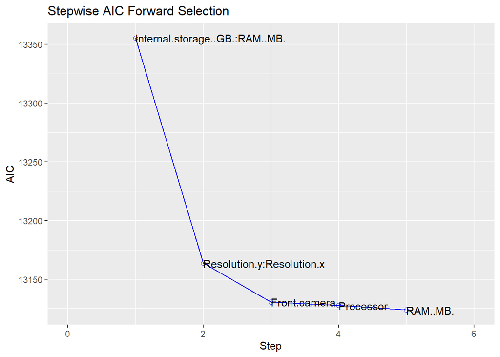

```r
plot(ols_step_forward_aic(modelfit), detail = T) #, color = "green"
```

Great acievement with Resolution feauters once again.

Now lets try backwards:

```r
ols_step_backward_aic(modelfit)
```

```
##
##
##                                 Backward Elimination Summary
## -------------------------------------------------------------------------------------------
## Variable                     AIC           RSS            Sum Sq        R-Sq      Adj. R-Sq
## -------------------------------------------------------------------------------------------
## Full Model                13126.789    11159052.836    13930190.851    0.55523      0.55108
## X4G..LTE                  13125.637    11167773.145    13921470.542    0.55488      0.55115
## Battery.capacity..mAh.    13124.815    11179901.889    13909341.798    0.55439      0.55108
## Internal.storage..GB.     13124.485    11197132.696    13892110.991    0.55371      0.55081
## -------------------------------------------------------------------------------------------
```

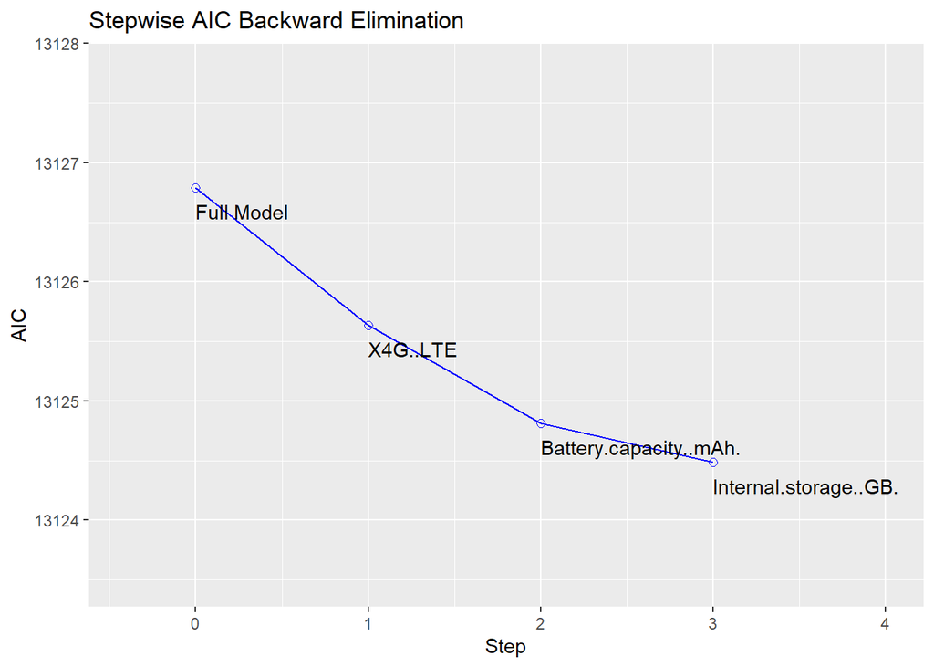

```r
plot(ols_step_backward_aic(modelfit), detail = T)
```

Now stepwise that consists on entering and removing predictors based on akaike information criteria, in a stepwise manner until there is no variable left to enter or remove any more.

```r
ols_step_backward_aic(modelfit)
```

[output not shown]

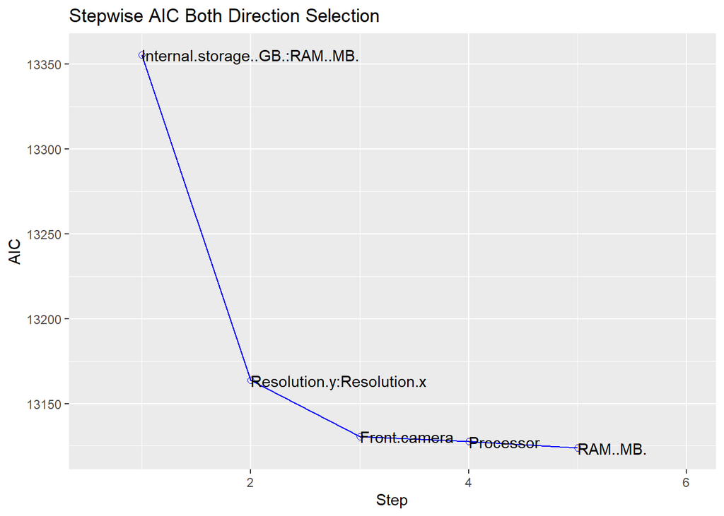

```r
plot(ols_step_both_aic(modelfit), detail = T)
```

So it is consider that the reasonable model will be really similar to the prev, but with few changes:

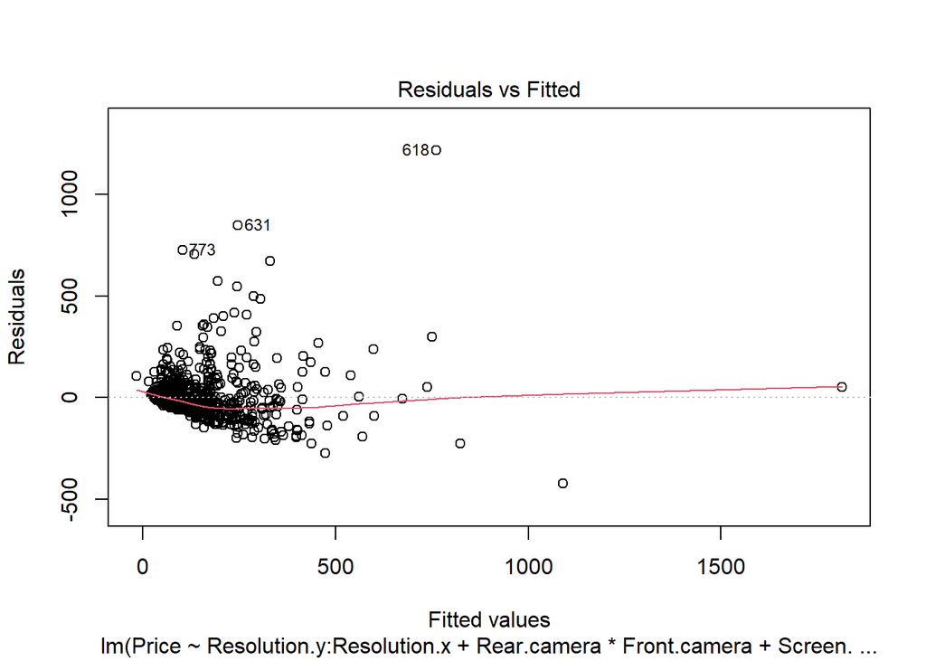

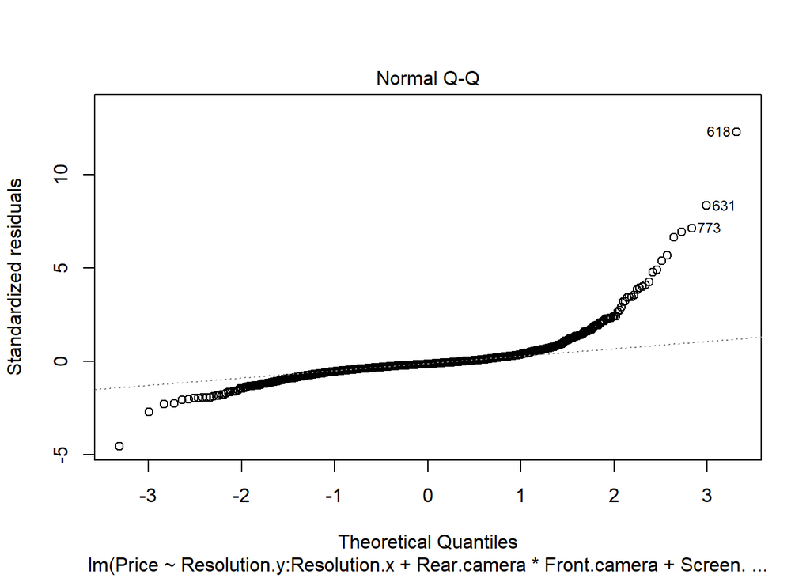

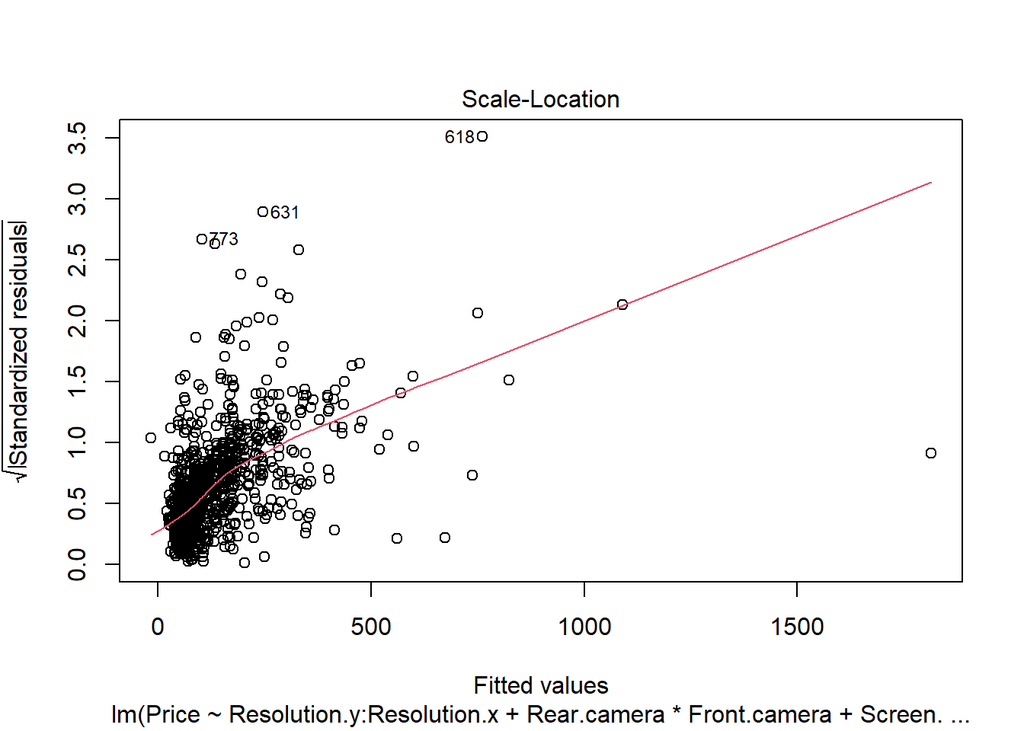

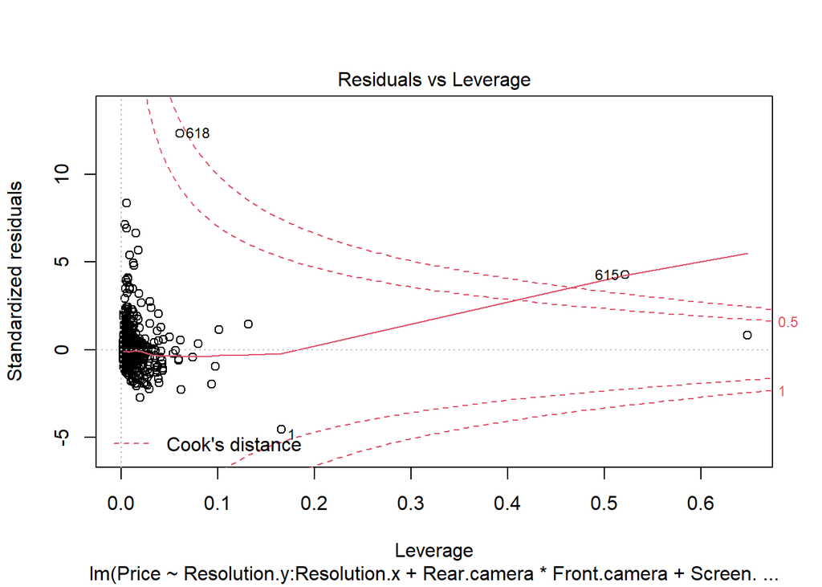

```r
modelfit = lm(Price ~ Resolution.y:Resolution.x + Rear.camera*Front.camera + Screen.size..inches. + Processor + Internal.storage..GB.*RAM..MB.+
                GPS, data = train_reg)
plot(modelfit)
```

```r
summary(modelfit)
```

```
##
## Call:
## lm(formula = Price ~ Resolution.y:Resolution.x + Rear.camera *
##     Front.camera + Screen.size..inches. + Processor + Internal.storage..GB. *
##     RAM..MB. + GPS, data = train_reg)
##
## Residuals:
##     Min      1Q  Median      3Q     Max
## -423.74  -38.00  -13.65   15.50 1216.31
##
## Coefficients:
##                                  Estimate Std. Error t value Pr(>|t|)
## (Intercept)                     3.826e+01  3.391e+01   1.128   0.2595
## Rear.camera                    -1.396e+00  8.808e-01  -1.584   0.1134
## Front.camera                   -5.560e+00  1.102e+00  -5.047 5.26e-07 ***
## Screen.size..inches.           -9.513e-01  7.485e+00  -0.127   0.8989
## Processor                      -4.536e+00  2.027e+00  -2.237   0.0255 *
## Internal.storage..GB.           4.100e-01  3.017e-01   1.359   0.1745
## RAM..MB.                        1.180e-02  4.688e-03   2.516   0.0120 *
## GPSYes                          1.756e+01  1.189e+01   1.477   0.1399
## Resolution.y:Resolution.x       6.132e-05  5.030e-06  12.190  < 2e-16 ***
## Rear.camera:Front.camera        7.076e-02  3.509e-02   2.017   0.0440 *
## Internal.storage..GB.:RAM..MB.  2.138e-04  3.181e-05   6.722 2.91e-11 ***
## ---
## Signif. codes:  0 '***' 0.001 '**' 0.01 '*' 0.05 '.' 0.1 ' ' 1
##
## Residual standard error: 101.9 on 1074 degrees of freedom
## Multiple R-squared:  0.5553, Adjusted R-squared:  0.5512
## F-statistic: 134.1 on 10 and 1074 DF,  p-value: < 2.2e-16
```

```r
#we are going to sabe this model for future algorithms
model_final = Price ~ Resolution.y:Resolution.x + Rear.camera*Front.camera + Screen.size..inches. + Processor + Internal.storage..GB.*RAM..MB.+
                GPS
```

$R^2$ has improved now so the analysis has been worthy.

Let see if the model still be as valuable for the testing set so:

```r
cor(predict(modelfit, newdata = test_reg), test_reg$Price)^2
```

```
## [1] 0.4986838
```

The R-squared is really simillar so the model is not overfitted.

The Root Mean Squared Error it is also valuable for watching the functionality of a model, it follows the formula:

$$RMSE = \sqrt{\frac{1}{n}\Sigma_{i=1}^{n}{\Big(y_i -\hat{y_i}\Big)^2}}$$

So:

```r
#RMSE
sqrt(mean((predict(modelfit, newdata = test_reg) - test_reg$Price)^2))
```

```
## [1] 123.3604
```

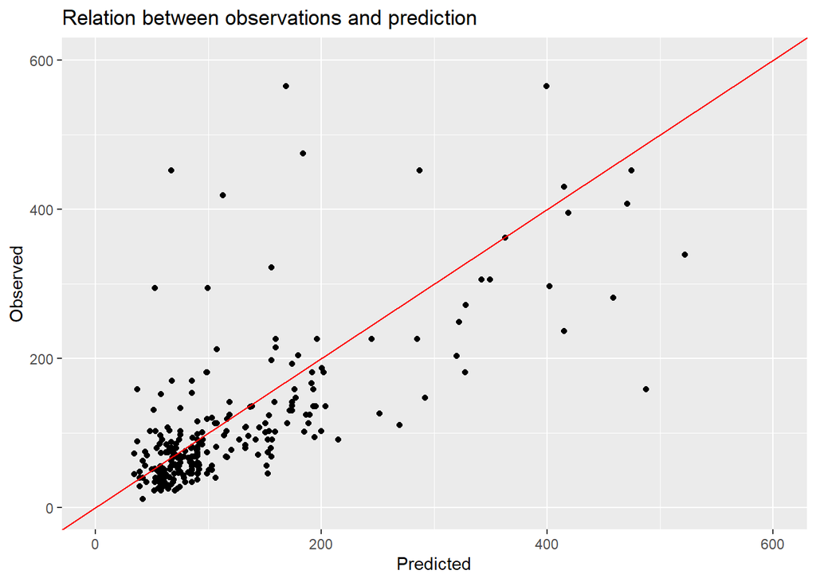

```r
qplot(predict(modelfit, newdata = test_reg), test_reg$Price)+geom_abline(intercept = 0, slope = 1, color = "red")+
  labs(x = "Predicted",y= "Observed",title = "Relation between observations and prediction")+xlim(c(0,600))+ylim(c(0,600))
```

## BENCHMARK

Before performing more sophisticated analysis it is good to perform a Benchmark that is kind of the worst model that can be done for predicition, In this case, data is going to be predicted with the only reference of the mean so the $R^2$ will be or at least, should be the worse of our whole analysis.

So the formula will be:

$$Y_{prediction} = \beta_o | \beta_0 =
\bar{y}$$

```r
intercept_value = mean(train_reg$Price)
```

```r
# RMSE
sqrt(mean((intercept_value- test_reg$Price)^2))
```

```
## [1] 174.4811
```

Obviously the root sum of squared errors is bigger in this case than in the previous model.

## Statistical Learning algorithms

We have to check some features that were analysed as correlated from the intital ggcorr graph, so it is seen that:

```r
cor(train_reg$Resolution.x,train_reg$Resolution.y)
```

```
## [1] 0.9172257
```

Some of them can not really show correlations near to 1 but they are correlated in a not LINEAR way, so lets analyse the plot of storage within memory

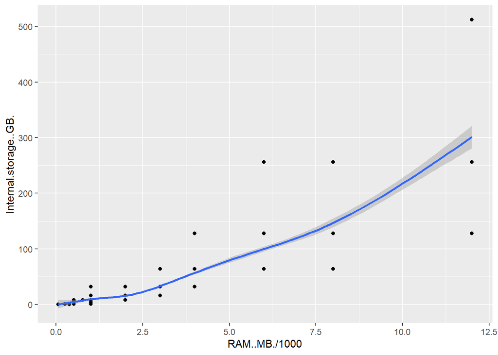

```r
ggplot(train_reg)+aes(x = RAM..MB./1000, y =Internal.storage..GB.)+geom_point()+
  geom_smooth()
```

```r
#The relation is almost linear

cor(train_reg$RAM..MB.,train_reg$Internal.storage..GB.)
```

```
## [1] 0.8294667
```

Those variables were already interacting between them in the previous model so:

We set the validation process that is wanted to be followed as a Repeated Cross Validation

This algorithm consists on the split of the data in k different folds or subsets. For k times, it selects all the folds as a training set except one, that is selected as a train set, and this test set, change every time we do this validation. When this process is finished we repeat it for the times setted by the “repeats” parameter. In this case, the k is 6, and repeats = 2,

```r
type_val = trainControl(method = "repeatedcv", number = 6, repeats = 2)
```

### LINEAR REGRESSION

So now let see how does a completely linear model work with caret training function:

```r
lin_model = train(Price ~ Resolution.y + Resolution.x + Rear.camera + Front.camera + Processor + Internal.storage..GB., data = train_reg,
                 method = "lm",
                 preProc=c('scale', 'center'),
                 trControl = type_val)
lin_model
```

```
## Linear Regression
##
## 1085 samples
##    6 predictor
##
## Pre-processing: scaled (6), centered (6)
## Resampling: Cross-Validated (6 fold, repeated 2 times)
## Summary of sample sizes: 904, 905, 905, 904, 903, 904, ...
## Resampling results:
##
##   RMSE      Rsquared   MAE
##   106.7927  0.4995537  59.23833
##
## Tuning parameter 'intercept' was held constant at a value of TRUE
```

Lower R-squared than in the initial model since this one is made with simple linear combinations.

In the teacher html it was consider to create a data frame to save the results, and i found it a good idea to select the best model at the end.

```r
results = data.frame(Price = test_reg$Price)
```

So the prediction of this model:

```r
results$lin_model = predict(lin_model, test_reg)
```

postResample function shows the behavior of the model with the test set, by three values(MAE(mean absolute error); R^2; RMSE) so it is a good way to compare:

```r
postResample(results$lin_model,results$Price)
```

```
##        RMSE    Rsquared         MAE
## 127.7856303   0.4614601  66.1784077
```

The relation between observation and prediction can be also seen in a graph.

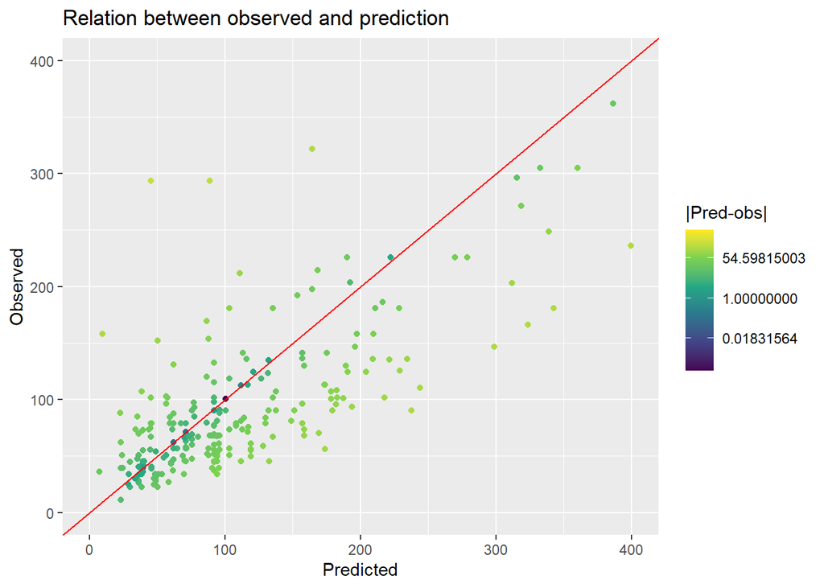

```r
qplot(results$lin_model, results$Price, color = abs(results$lin_model-results$Price))+geom_abline(intercept = 0, slope = 1, color = "red")+
  labs(x = "Predicted",y= "Observed",title = "Relation between observed and prediction")+xlim(c(0,400))+ylim(c(0,400))+scale_color_viridis_c(trans = "log", name = "|Pred-obs|")
```

As we can see, the data is not that well predicted since the red line is the ideal prediction and not all the points are really close to the line.

Low price devices are better classified than the expensive ones. There is a high BIAS present.

### Overfitted regression

How would it work with more features included so the model will overfitts?

```r
levels(train_reg) = levels(data$Operating.system)

ov_lin_model = train(Price ~ Resolution.y + Resolution.x + Rear.camera + Front.camera + Screen.size..inches. + Processor + Internal.storage..GB.+ RAM..MB.+ GPS + Operating.system+ Touchscreen+ Bluetooth, data = train_reg,
                 method = "lm",
                 preProc=c('scale', 'center'),
                 trControl = type_val)

ov_lin_model
```

```
## Linear Regression
##
## 1085 samples
##   12 predictor
##
## Pre-processing: scaled (15), centered (15)
## Resampling: Cross-Validated (6 fold, repeated 2 times)
## Summary of sample sizes: 905, 903, 905, 905, 904, 903, ...
## Resampling results:
##
##   RMSE      Rsquared   MAE
##   103.2376  0.5308295  57.39741
##
## Tuning parameter 'intercept' was held constant at a value of TRUE
```

Prediction

```r
results$ov_lin_model = predict(ov_lin_model, test_reg)
postResample(results$ov_lin_model,results$Price)
```

```
##        RMSE    Rsquared         MAE
## 117.0338885   0.5482815  62.9875576
```

The overfitted data describes better the variability than the simple linear model.

The qplot is:

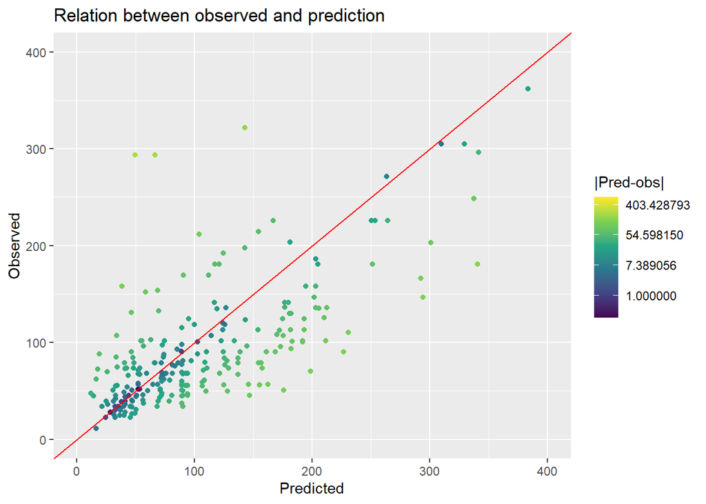

```r
qplot(results$ov_lin_model, results$Price, color = abs(results$ov_lin_model-results$Price))+geom_abline(intercept = 0, slope = 1, color = "red")+
  labs(x = "Predicted",y= "Observed",title = "Relation between observed and prediction")+xlim(c(0,400))+ylim(c(0,400))+scale_color_viridis_c(trans = "log", name = "|Pred-obs|")
```

Little less bias appreciated since the values seems to be closer to the red line.

Although this result is obtained, we need to remark that overfitting is used to be very dangerous because the coefficients are affected by lot of noise. Nonetheless, this model works better with this split than the normal linear regression

### Forward Regression

```r
forw_model =train(model_final, data = train_reg,
                  preProc=c('scale', 'center'), method = "leapForward",
                  tuneGrid = expand.grid(nvmax =2:11), # maximum size of subsets to examine
                  trControl = type_val)

forw_model
```

```
## Linear Regression with Forward Selection
##
## 1085 samples
##    9 predictor
##
## Pre-processing: scaled (10), centered (10)
## Resampling: Cross-Validated (6 fold, repeated 2 times)
## Summary of sample sizes: 904, 904, 905, 905, 903, 904, ...
## Resampling results across tuning parameters:
##
##   nvmax  RMSE      Rsquared   MAE
##    2     102.3894  0.5199747  55.41713
##    3     101.9704  0.5419923  54.82463
##    4     102.7615  0.5358225  55.39150
##    5     101.9354  0.5393871  55.23842
##    6     102.3531  0.5333827  55.44417
##    7     102.8311  0.5317725  55.76784
##    8     103.1074  0.5277811  56.10664
##    9     103.0191  0.5276169  56.18222
##   10     103.0783  0.5270924  56.20091
##   11     103.0783  0.5270924  56.20091
##
## RMSE was used to select the optimal model using the smallest value.
## The final value used for the model was nvmax = 5.
```

So nvmax = 5 is chosen:

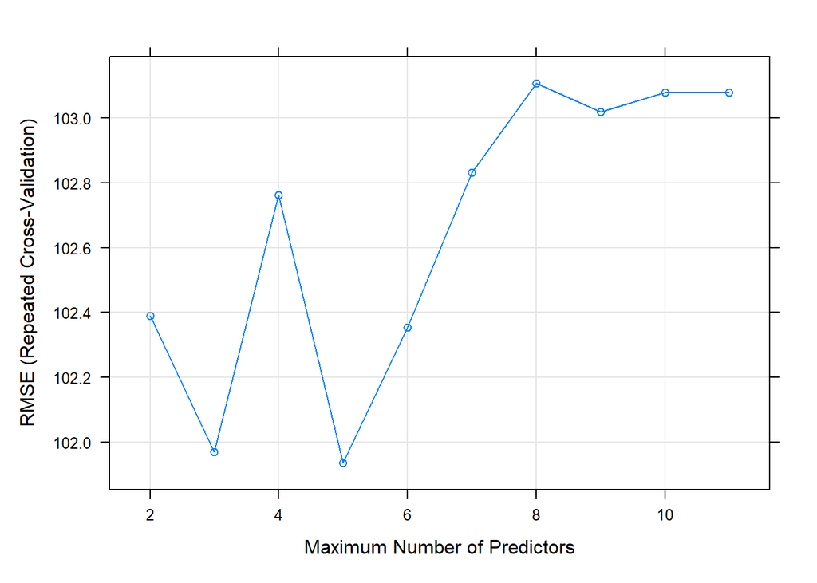

```r
plot(forw_model)
```

The RMSE it is clearly seen that reaches its minimum when there are only 5 predictors.

The $R^2$ is not really increased in this proccedure, anyway lets see what 5 variables where chosen for predicting:

```r
coef(forw_model$finalModel,forw_model$bestTune$nvmax)
```

```
##                    (Intercept)                   Front.camera
##                      127.18442                      -24.13049
##                      Processor                       RAM..MB.
##                      -11.64347                       17.29408
##      Resolution.y:Resolution.x Internal.storage..GB.:RAM..MB.
##                       58.73306                       76.34028
```

Finally the variables that affect the most are this 5. As seen previously Resolution mix and StoragevsMemory are the features that affeccts the most to Price in smartphones.

```r
results$forw_model = predict(forw_model, test_reg)
postResample(results$forw_model,results$Price)
```

```
##      RMSE  Rsquared       MAE
## 123.95545   0.49435  62.27222
```

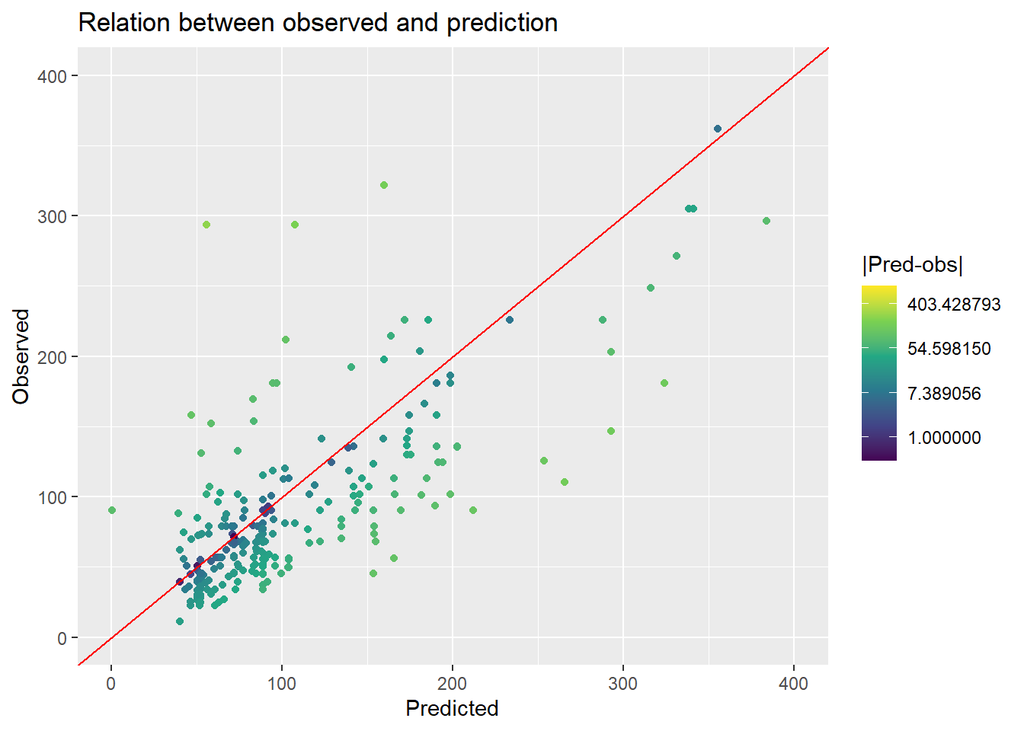

```r
qplot(results$forw_model, results$Price, color = abs(results$forw_model-results$Price))+geom_abline(intercept = 0, slope = 1, color = "red")+
  labs(x = "Predicted",y= "Observed",title = "Relation between observed and prediction")+xlim(c(0,400))+ylim(c(0,400))+scale_color_viridis_c(trans = "log", name = "|Pred-obs|")
```

Not really appreciable improvement.

### Stepwise & Backward Regression

```r
step_model = train(model_final, data = train_reg,
                  preProc=c('scale', 'center'), method = "leapSeq",
                  tuneGrid = expand.grid(nvmax =2:11), # maximum size of subsets to examine
                  trControl = type_val)
backw_model = train(model_final, data = train_reg,
                  preProc=c('scale', 'center'), method = "leapBackward",
                  tuneGrid = expand.grid(nvmax =2:11), # maximum size of subsets to examine
                  trControl = type_val)
step_model
```

```
## Linear Regression with Stepwise Selection
##
## 1085 samples
##    9 predictor
##
## Pre-processing: scaled (10), centered (10)
## Resampling: Cross-Validated (6 fold, repeated 2 times)
## Summary of sample sizes: 905, 904, 903, 903, 905, 905, ...
## Resampling results across tuning parameters:
##
##   nvmax  RMSE      Rsquared   MAE
##    2     101.6551  0.5317108  54.76002
##    3     100.0275  0.5478720  53.89891
##    4     108.9831  0.4768431  57.92499
##    5     101.3032  0.5365845  55.03386
##    6     102.7021  0.5247668  55.39504
##    7     103.2438  0.5185302  56.46317
##    8     103.2338  0.5224895  57.07051
##    9     103.1347  0.5230183  56.71078
##   10     102.4667  0.5273023  55.78843
##   11     102.4667  0.5273023  55.78843
##
## RMSE was used to select the optimal model using the smallest value.
## The final value used for the model was nvmax = 3.
```

```r
backw_model
```

```
## Linear Regression with Backwards Selection
##
## 1085 samples
##    9 predictor
##
## Pre-processing: scaled (10), centered (10)
## Resampling: Cross-Validated (6 fold, repeated 2 times)
## Summary of sample sizes: 904, 905, 904, 904, 905, 903, ...
## Resampling results across tuning parameters:
##
##   nvmax  RMSE      Rsquared   MAE
##    2     103.0250  0.5171287  55.08904
##    3     102.0933  0.5245273  54.59357
##    4     102.8241  0.5195210  54.83173
##    5     103.6383  0.5131260  55.37002
##    6     103.9195  0.5126340  55.63060
##    7     104.0459  0.5113634  55.92633
##    8     104.0288  0.5126246  56.05730
##    9     104.3209  0.5100416  56.17903
##   10     104.4940  0.5091574  56.22135
##   11     104.4940  0.5091574  56.22135
##
## RMSE was used to select the optimal model using the smallest value.
## The final value used for the model was nvmax = 3.
```

Plotting the evolution of the models with the different number of predictors

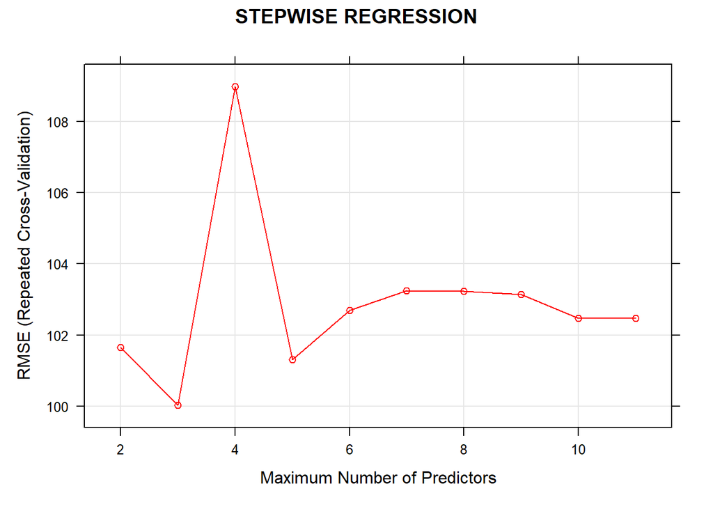

```r
par(mfrow=c(2,2))
plot(step_model, col ="red", main = "STEPWISE REGRESSION")
```

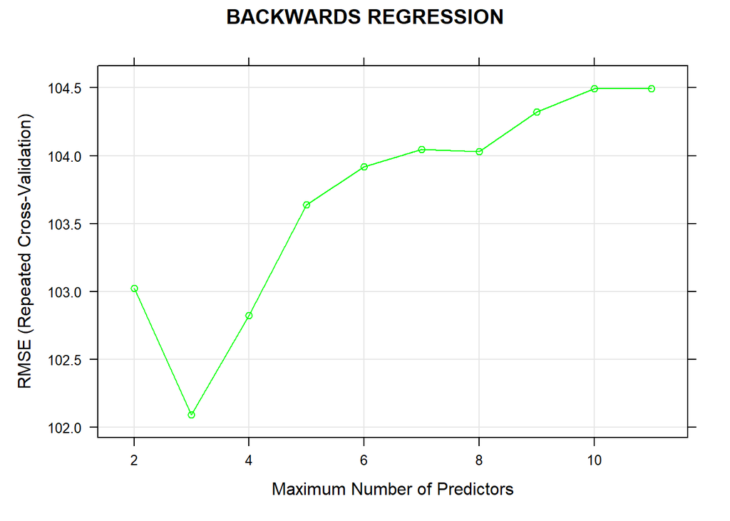

```r
plot(backw_model, col ="green", main = "BACKWARDS REGRESSION")
```

Variables selected in each

```r
#STEPWISE MODEL
coef(step_model$finalModel,step_model$bestTune$nvmax)
```

```
##                    (Intercept)                   Front.camera
##                      127.18442                      -22.37738
##      Resolution.y:Resolution.x Internal.storage..GB.:RAM..MB.
##                       59.83715                       84.03984
```

It only selects the 3 most important variables of the regression

```r
#BACKWARDS MODEL
coef(backw_model$finalModel,backw_model$bestTune$nvmax)
```

```
##                    (Intercept)                   Front.camera
##                      127.18442                      -22.37738
##      Resolution.y:Resolution.x Internal.storage..GB.:RAM..MB.
##                       59.83715                       84.03984
```

PREDICTION:

```r
results$backw_model = predict(backw_model, test_reg)
results$step_model = predict(step_model, test_reg)

print("BACKWARD REGRESSION")
```

```
## [1] "BACKWARD REGRESSION"
```

```r
postResample(results$backw_model,results$Price)
```

```
##        RMSE    Rsquared         MAE
## 124.7567922   0.4870669  61.7613280
```

```r
print("STEPWISE REGRESSION")
```

```
## [1] "STEPWISE REGRESSION"
```

```r
postResample(results$step_model,results$Price)
```

```
##        RMSE    Rsquared         MAE
## 124.7567922   0.4870669  61.7613280
```

Reallly similar values to previous analysis.

Lets see the plots in order to see the differences. Using ggarrange() we are able to watch the graphs together:

```r
library(ggpubr)
```

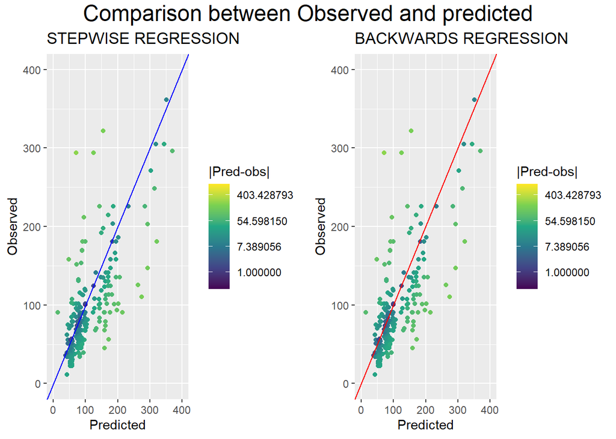

```r
p = ggarrange(qplot(results$step_model, results$Price, color = abs(results$step_model-results$Price))+geom_abline(intercept = 0, slope = 1, color = "blue")+
  labs(x = "Predicted",y= "Observed",title = "STEPWISE REGRESSION")+xlim(c(0,400))+ylim(c(0,400))+scale_color_viridis_c(trans = "log", name = "|Pred-obs|"),
  qplot(results$backw_model, results$Price, color = abs(results$backw_model-results$Price))+geom_abline(intercept = 0, slope = 1, color = "red")+
  labs(x = "Predicted",y= "Observed",title = "BACKWARDS REGRESSION")+xlim(c(0,400))+ylim(c(0,400))+scale_color_viridis_c(trans = "log", name = "|Pred-obs|")
)
annotate_figure(p,
                top = text_grob("Comparison between Observed and predicted", color = "black", size = 18))
```

##PENALIZED REGRESSION ALGORITHMS ### RIDGE REGRESSION

This regression is a type of regularization that imposes a penalty on the coefficients of the model to reduce their magnitude. it is useful because we can prevent overfitting and improve the generalization of the model with unseen data.

We need to create a grid for the lambda hyperparameter. This hyperparameter controls the bias-variance tradeoff. Hence when lambda is 0, the penalty term has no effect, and ridge regression will produce the classical least square coefficients. However, as λ increases to infinite, the impact of the shrinkage penalty grows, and the ridge regression coefficients will get close zero.

Caret package is going to be used although glm can also be used. Results with both libraries are really similar.

```r
library(elasticnet)
grid_ridge_shrinkage = expand.grid(lambda = seq(0, 0.5, 0.002))

#using caret package
ridge_model = train(model_final, data = train_reg, tuneGrid = grid_ridge_shrinkage,method='ridge',
                    preProc=c('scale','center'),trControl=type_val)
ridge_model
```

```
## Ridge Regression
##
## 1085 samples
##    9 predictor
##
## Pre-processing: scaled (10), centered (10)
## Resampling: Cross-Validated (6 fold, repeated 2 times)
## Summary of sample sizes: 904, 902, 905, 905, 904, 905, ...
## Resampling results across tuning parameters:
##
##   lambda  RMSE      Rsquared   MAE
##   0.000   103.4282  0.5171694  55.79911
##   0.002   103.3376  0.5173239  55.76537
##   0.004   103.2609  0.5174545  55.73431
##   0.006   103.1955  0.5175648  55.70582
##   0.008   103.1396  0.5176579  55.67979
##   0.010   103.0914  0.5177361  55.65558
##   0.012   103.0497  0.5178014  55.63364
##   0.014   103.0137  0.5178554  55.61382
##   0.016   102.9824  0.5178994  55.59635
##   0.018   102.9553  0.5179346  55.58031
##   0.020   102.9318  0.5179619  55.56602
##   0.022   102.9114  0.5179822  55.55354
##   0.024   102.8939  0.5179963  55.54218
##   0.026   102.8788  0.5180047  55.53191
##   0.028   102.8659  0.5180080  55.52318
##   0.030   102.8549  0.5180066  55.51566
##   0.032   102.8458  0.5180009  55.50923
##   0.034   102.8383  0.5179914  55.50338
##   0.036   102.8322  0.5179784  55.49801
##   0.038   102.8274  0.5179620  55.49349
##   0.040   102.8239  0.5179427  55.48942
##   0.042   102.8215  0.5179206  55.48620
##   0.044   102.8201  0.5178958  55.48352
##   0.046   102.8197  0.5178687  55.48214
##   0.048   102.8202  0.5178393  55.48125
##   0.050   102.8215  0.5178079  55.48086
##   0.052   102.8236  0.5177745  55.48121
##   0.054   102.8264  0.5177393  55.48262
##   0.056   102.8299  0.5177023  55.48483
```

[output cut: 210 more lines]

```
##   0.478   108.3794  0.5020250  63.13557
##   0.480   108.4194  0.5019462  63.19255
##   0.482   108.4594  0.5018674  63.24960
##   0.484   108.4995  0.5017887  63.30668
##   0.486   108.5398  0.5017100  63.36387
##   0.488   108.5801  0.5016314  63.42109
##   0.490   108.6205  0.5015529  63.47851
##   0.492   108.6610  0.5014744  63.53594
##   0.494   108.7016  0.5013960  63.59331
##   0.496   108.7423  0.5013176  63.65064
##   0.498   108.7831  0.5012393  63.70793
##   0.500   108.8240  0.5011610  63.76531
##
## RMSE was used to select the optimal model using the smallest value.
## The final value used for the model was lambda = 0.046.
```

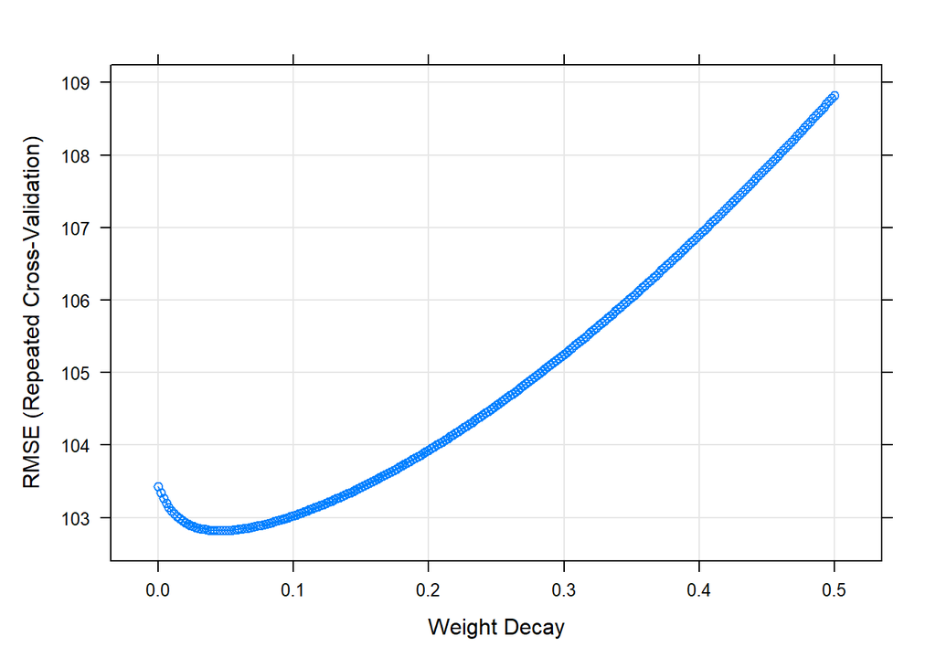

```r
plot(ridge_model)
```

The graph show how the least RMSE is obtained near 0.05

Lets see which lambda works the best for the RMSE to be the lowest possible

```r
ridge_model$bestTune
```

```
##    lambda
## 24  0.046
```

PREDICTIONS:

```r
results$ridge_model = predict(ridge_model, test_reg)
postResample(results$ridge_model,results$Price)
```

```
##        RMSE    Rsquared         MAE
## 123.8065780   0.4960116  62.6164338
```

###LASSO Regression

This regression is another type of penalized regression.

In this method, we have a penalty term that tries to make coefficients that do not affect deeply into the model, to reach 0.

So:

```r
grid_lasso_shrinkage = expand.grid(fraction = seq(0, 1, 0.005))

lasso_model = train(model_final, data = train_reg, tuneGrid = grid_lasso_shrinkage,method='lasso',
                    preProc=c('scale','center'),trControl=type_val)
lasso_model
```

```
## The lasso
##
## 1085 samples
##    9 predictor
##
## Pre-processing: scaled (10), centered (10)
## Resampling: Cross-Validated (6 fold, repeated 2 times)
## Summary of sample sizes: 903, 905, 904, 904, 904, 905, ...
## Resampling results across tuning parameters:
##
##   fraction  RMSE      Rsquared   MAE
##   0.000     149.1600        NaN  86.24867
##   0.005     148.4194  0.4133817  85.79122
##   0.010     147.6930  0.4152027  85.34685
##   0.015     146.9713  0.4157976  84.90585
##   0.020     146.2519  0.4160017  84.46151
##   0.025     145.5365  0.4160114  84.01594
##   0.030     144.8262  0.4159774  83.57352
##   0.035     144.1210  0.4159346  83.13365
##   0.040     143.4213  0.4158929  82.69496
##   0.045     142.7494  0.4159308  82.25924
##   0.050     142.1069  0.4165625  81.82420
##   0.055     141.4834  0.4177070  81.38996
##   0.060     140.8686  0.4187333  80.96018
##   0.065     140.2578  0.4195855  80.53598
##   0.070     139.6583  0.4209276  80.10590
##   0.075     139.0680  0.4221137  79.67812
##   0.080     138.4828  0.4233071  79.24972
##   0.085     137.9033  0.4247877  78.82382
##   0.090     137.3289  0.4259687  78.40303
##   0.095     136.7556  0.4269849  77.98228
##   0.100     136.1863  0.4278137  77.56432
##   0.105     135.6224  0.4284685  77.15997
##   0.110     135.0642  0.4289823  76.76448
##   0.115     134.5115  0.4293812  76.37698
##   0.120     133.9407  0.4302158  75.99678
##   0.125     133.3683  0.4317447  75.61434
##   0.130     132.8013  0.4330955  75.23650
##   0.135     132.2388  0.4344118  74.86302
##   0.140     131.6682  0.4367364  74.47764
```

[output cut: 160 more lines]

```
##   0.945     102.5499  0.5221844  55.55626
##   0.950     102.5675  0.5220367  55.58277
##   0.955     102.5854  0.5218867  55.60934
##   0.960     102.6036  0.5217343  55.63604
##   0.965     102.6218  0.5215824  55.66319
##   0.970     102.6359  0.5214754  55.69005
##   0.975     102.6502  0.5213663  55.71714
##   0.980     102.6649  0.5212550  55.74457
##   0.985     102.6798  0.5211415  55.77209
##   0.990     102.6948  0.5210246  55.79988
##   0.995     102.7102  0.5209057  55.82774
##   1.000     102.7253  0.5207886  55.85571
##
## RMSE was used to select the optimal model using the smallest value.
## The final value used for the model was fraction = 0.67.
```

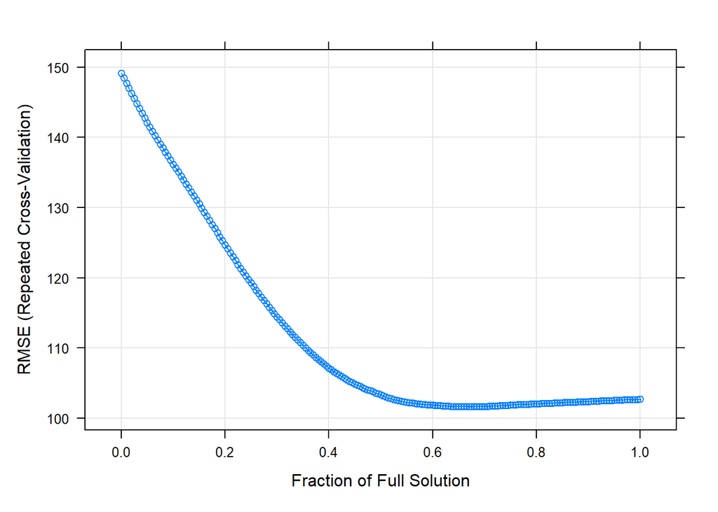

```r
plot(lasso_model)
```

```r
lasso_model$bestTune
```

```
##     fraction
## 135     0.67
```

PREDICTIONS:

```r
results$lasso_model = predict(lasso_model, test_reg)
postResample(results$lasso_model,results$Price)
```

```
##        RMSE    Rsquared         MAE
## 124.0544389   0.4920606  60.7743176
```

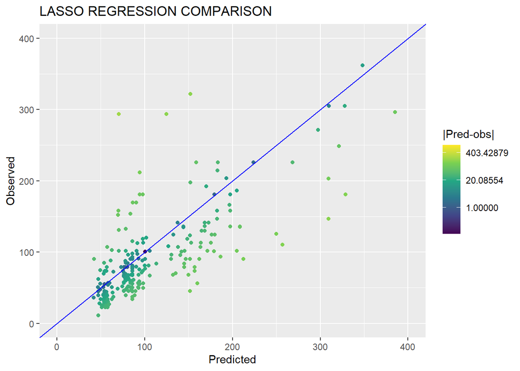

```r
qplot(results$lasso_model, results$Price, color = abs(results$lasso_model-results$Price))+geom_abline(intercept = 0, slope = 1, color = "blue")+
  labs(x = "Predicted",y= "Observed",title = "LASSO REGRESSION COMPARISON")+xlim(c(0,400))+ylim(c(0,400))+scale_color_viridis_c(trans = "log", name = "|Pred-obs|")
```

The 3 values have not improved until now. They present similar values in all this linear regressions. I guess that this is not going to be amazingly improved with linear formulas.

###ELASTIC NET

Finally, this its the last Penalized Regression algorithm that it is going to be tried since linear regression seems not to improve significantly the model.

Elastic net is a model that combines properties of Ridge and Lasso models and tries to balance the simplicity and the minimization of the prediction error.

As it is a combination, it takes the parameter of both algorithms to perform his.

```r
grid_elastic_shrinkage = expand.grid(alpha = seq(0, 0.5, 0.05), lambda = seq(0, 0.15, 0.01))

elastic_model = train(model_final, data = train_reg, tuneGrid = grid_elastic_shrinkage,method='glmnet',
                    preProc=c('scale','center'),trControl=type_val)

elastic_model
```

```
## glmnet
##
## 1085 samples
##    9 predictor
##
## Pre-processing: scaled (10), centered (10)
## Resampling: Cross-Validated (6 fold, repeated 2 times)
## Summary of sample sizes: 904, 903, 905, 902, 905, 906, ...
## Resampling results across tuning parameters:
##
##   alpha  lambda  RMSE      Rsquared   MAE
##   0.00   0.00    102.5542  0.5119415  55.24770
##   0.00   0.01    102.5542  0.5119415  55.24770
##   0.00   0.02    102.5542  0.5119415  55.24770
##   0.00   0.03    102.5542  0.5119415  55.24770
##   0.00   0.04    102.5542  0.5119415  55.24770
##   0.00   0.05    102.5542  0.5119415  55.24770
##   0.00   0.06    102.5542  0.5119415  55.24770
##   0.00   0.07    102.5542  0.5119415  55.24770
##   0.00   0.08    102.5542  0.5119415  55.24770
##   0.00   0.09    102.5542  0.5119415  55.24770
##   0.00   0.10    102.5542  0.5119415  55.24770
##   0.00   0.11    102.5542  0.5119415  55.24770
##   0.00   0.12    102.5542  0.5119415  55.24770
##   0.00   0.13    102.5542  0.5119415  55.24770
##   0.00   0.14    102.5542  0.5119415  55.24770
##   0.00   0.15    102.5542  0.5119415  55.24770
##   0.05   0.00    102.6905  0.5106339  55.68254
##   0.05   0.01    102.6905  0.5106339  55.68254
##   0.05   0.02    102.6905  0.5106339  55.68254
##   0.05   0.03    102.6905  0.5106339  55.68254
##   0.05   0.04    102.6905  0.5106339  55.68254
##   0.05   0.05    102.6905  0.5106339  55.68254
##   0.05   0.06    102.6905  0.5106339  55.68254
##   0.05   0.07    102.6905  0.5106339  55.68254
##   0.05   0.08    102.6905  0.5106339  55.68254
##   0.05   0.09    102.6905  0.5106339  55.68254
##   0.05   0.10    102.6905  0.5106339  55.68254
##   0.05   0.11    102.6905  0.5106339  55.68254
##   0.05   0.12    102.6905  0.5106339  55.68254
```

[output cut: 135 more lines]

```
##   0.50   0.04    102.6511  0.5110779  55.61905
##   0.50   0.05    102.6511  0.5110779  55.61905
##   0.50   0.06    102.6511  0.5110779  55.61905
##   0.50   0.07    102.6511  0.5110779  55.61905
##   0.50   0.08    102.6511  0.5110779  55.61905
##   0.50   0.09    102.6511  0.5110779  55.61905
##   0.50   0.10    102.6511  0.5110779  55.61905
##   0.50   0.11    102.6511  0.5110779  55.61905
##   0.50   0.12    102.6511  0.5110779  55.61905
##   0.50   0.13    102.6509  0.5110791  55.61834
##   0.50   0.14    102.6506  0.5110809  55.61725
##   0.50   0.15    102.6503  0.5110827  55.61609
##
## RMSE was used to select the optimal model using the smallest value.
## The final values used for the model were alpha = 0 and lambda = 0.15.
```

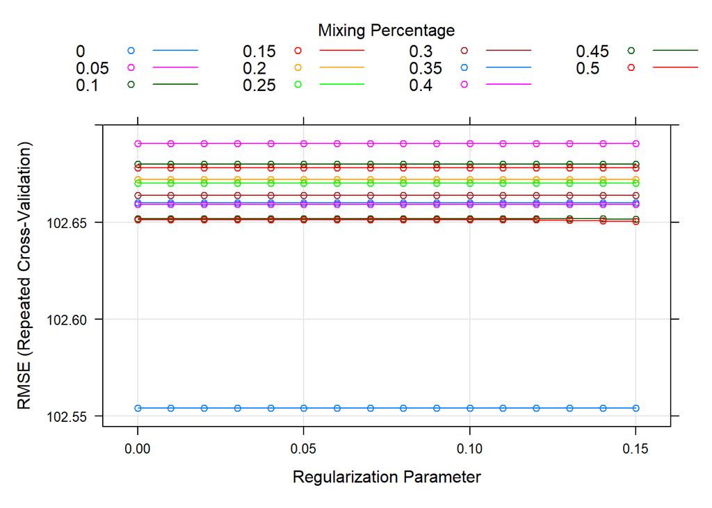

```r
plot(elastic_model)
```

Alpha 0 seems to work better than the other alphas. Let’s see then how it work in predcition

The best combination of hyperparameters is:

```r
elastic_model$bestTune
```

```
##    alpha lambda
## 16     0   0.15
```

Predicting:

```r
results$elastic_model = predict(elastic_model, test_reg)
postResample(results$elastic_model,results$Price)
```

```
##        RMSE    Rsquared         MAE
## 123.6678176   0.4952222  61.9450018
```

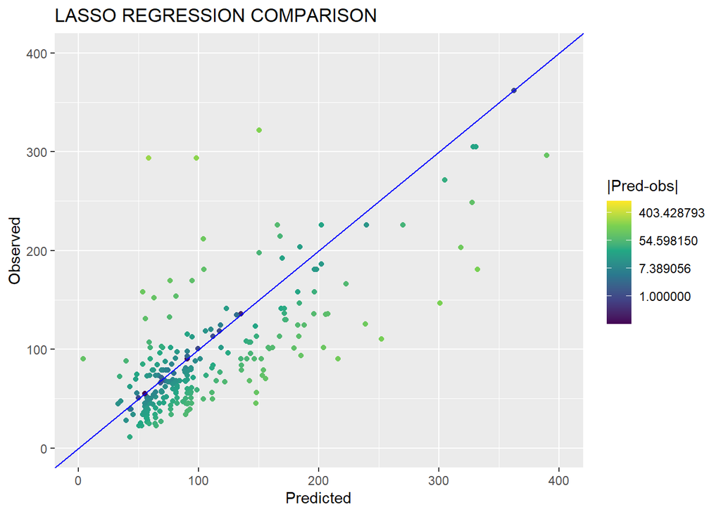

```r
#plotting values
qplot(results$elastic_model, results$Price, color = abs(results$elastic_model-results$Price))+geom_abline(intercept = 0, slope = 1, color = "blue")+
  labs(x = "Predicted",y= "Observed",title = "LASSO REGRESSION COMPARISON")+xlim(c(0,400))+ylim(c(0,400))+scale_color_viridis_c(trans = "log", name = "|Pred-obs|")
```

No great improvement needed.

## MACHINE LEARNING

Now lets see the performance with machine learning models such as knn algorithm and random Forest.

### KNN

The k-Nearest Neighbors (k-NN) is a regression algorithm that is based on the idea of identifying the k-nearest data points to a given input, and using the value of those points to make a prediction.

It first calculates the distance between the new point and all the points in the training dataset.Then, it selects the k points in the training dataset that are closest to the new point and assigns the new point to the class that is most common among those k points.

So knowing that we have to see the number of hyperparameters that we would need to optimize:

```r
modelLookup('kknn')
```

```
##   model parameter           label forReg forClass probModel
## 1  kknn      kmax Max. #Neighbors   TRUE     TRUE      TRUE
## 2  kknn  distance        Distance   TRUE     TRUE      TRUE
## 3  kknn    kernel          Kernel   TRUE     TRUE      TRUE
```

So lets fit the model:

```r
knn_model = train(model_final, data = train_reg, method = "kknn", preProc=c('scale','center'),
                  tuneGrid = expand.grid(kmax=c(8,10,12,14,16,18,20,22),distance=c(1,2,3),kernel='optimal'),
                  trControl=type_val)

knn_model
```

```
## k-Nearest Neighbors
##
## 1085 samples
##    9 predictor
##
## Pre-processing: scaled (10), centered (10)
## Resampling: Cross-Validated (6 fold, repeated 2 times)
## Summary of sample sizes: 905, 905, 904, 903, 903, 905, ...
## Resampling results across tuning parameters:
##
##   kmax  distance  RMSE      Rsquared   MAE
##    8    1         106.6686  0.4910781  52.38138
##    8    2         107.5778  0.4825942  53.53633
##    8    3         107.5621  0.4807443  53.94723
##   10    1         106.9760  0.4907519  52.31730
##   10    2         107.1600  0.4859621  52.98869
##   10    3         107.2576  0.4835995  53.54322
##   12    1         107.1443  0.4906427  52.30909
##   12    2         107.3664  0.4855563  52.99492
##   12    3         107.2362  0.4837181  53.53061
##   14    1         107.1443  0.4906427  52.30909
##   14    2         107.1276  0.4860639  53.01851
##   14    3         107.2576  0.4835995  53.54322
##   16    1         107.1374  0.4901982  52.25886
##   16    2         107.4369  0.4846842  53.13526
##   16    3         107.2362  0.4837181  53.53061
##   18    1         107.1666  0.4907675  52.28335
##   18    2         107.3478  0.4853963  53.03841
##   18    3         107.4321  0.4828876  53.58577
##   20    1         107.1066  0.4904943  52.23221
##   20    2         107.0012  0.4862309  52.99792
##   20    3         107.1615  0.4836039  53.47161
##   22    1         107.2382  0.4905023  52.22051
##   22    2         107.1229  0.4862928  52.94532
##   22    3         107.2077  0.4841048  53.48512
##
## Tuning parameter 'kernel' was held constant at a value of optimal
## RMSE was used to select the optimal model using the smallest value.
## The final values used for the model were kmax = 8, distance = 1 and kernel
##  = optimal.
```

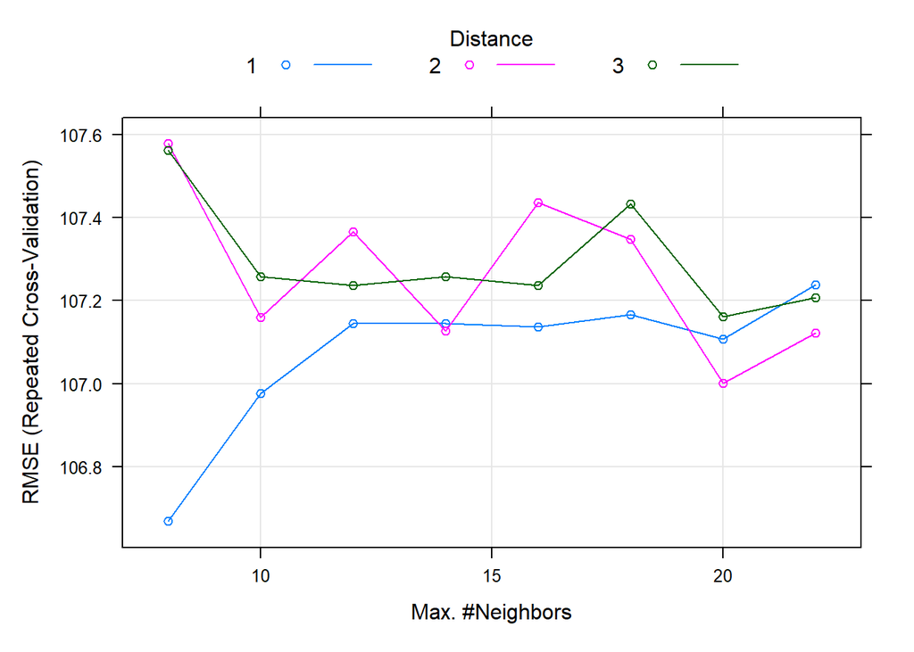

```r
plot(knn_model)
```

```r
results$knn_model = predict(knn_model, test_reg)
postResample(results$knn_model,results$Price)
```

```
##        RMSE    Rsquared         MAE
## 106.9805309   0.6365379  51.1281516
```

It is important to remark that this models are not linear so it is clear that it is a reason why we increase the R-squared that what stacked in the linear regression methods.

### Random Forest

This algorithm(that was already explained with Classification).

The key on this algorithm is to train a large number of decision trees on random subsets of the data, and then average their predictions to make a final prediction. With classification it uses the class that appeared the most and with regression it computes the mean among all the decision tree results.

I set a number of 400 trees to try decreasing the mistakes that can be done in some trees regression.

```r
rf_model = train(model_final, data = train_reg, method = "rf", preProc=c('scale','center'),ntree = 400,
                  tuneGrid = data.frame(mtry=c(3,5,7,9,11)),
                  trControl=type_val)
rf_model
```

```
## Random Forest
##
## 1085 samples
##    9 predictor
##
## Pre-processing: scaled (10), centered (10)
## Resampling: Cross-Validated (6 fold, repeated 2 times)
## Summary of sample sizes: 905, 903, 904, 903, 905, 905, ...
## Resampling results across tuning parameters:
##
##   mtry  RMSE      Rsquared   MAE
##    3    96.44392  0.6120240  49.58699
##    5    96.55630  0.6096446  50.03449
##    7    97.42674  0.6008162  50.45966
##    9    97.59913  0.6007218  50.45871
##   11    97.20282  0.6009072  50.52197
##
## RMSE was used to select the optimal model using the smallest value.
## The final value used for the model was mtry = 3.
```

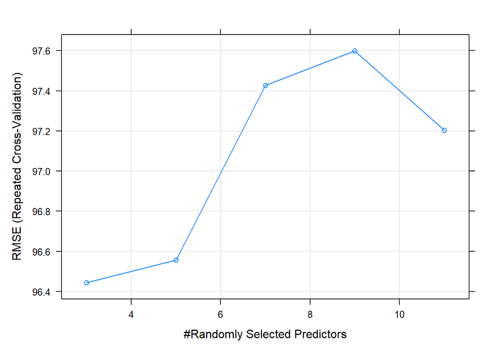

```r
plot(rf_model)
```

Great reduction in model RMSE, but will it remain with the testing set?

Variable importance can be computed in this section too.

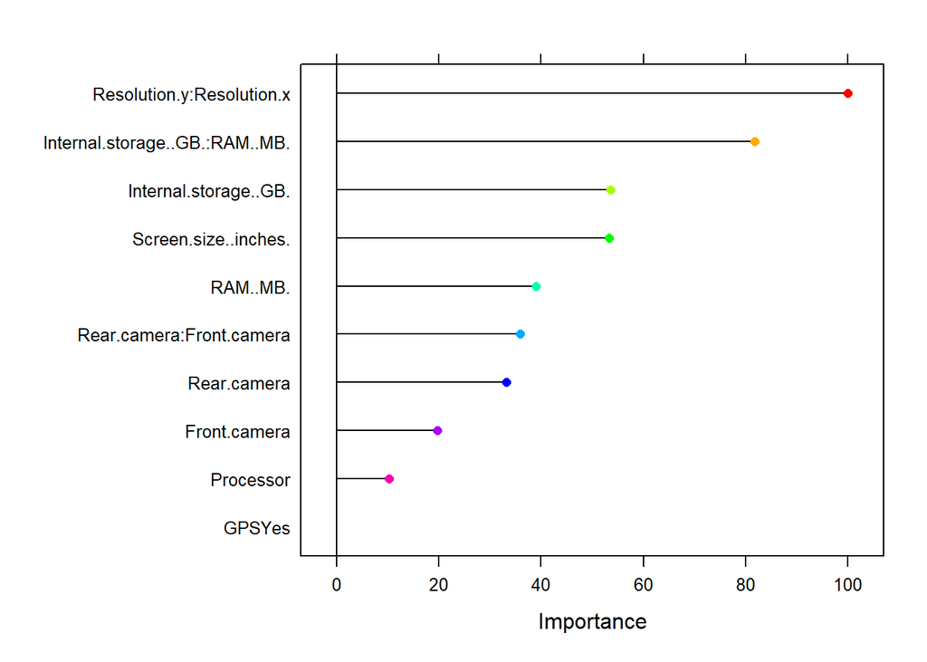

```r
plot(varImp(rf_model), col = rainbow(9))
```

The 2 first variables are indeed the most important during all the algorithms so it is not surprising. Furthermore, Resolution is almost Reaching 100 in importance. In the other hand, GPS is a variable that do not affect almost in anything in this method.

PREDICTION:

```r
results$rf_model = predict(rf_model, test_reg)
postResample(results$rf_model,results$Price)
```

```
##        RMSE    Rsquared         MAE
## 103.4697671   0.6482789  53.4510375
```

More improvement with this algorithm. It is clear that non-regression is fittin better models.

### Gradient Boosting

Finally, the last method is gradient boosting. Also performed in Classification analysis.

As a brief introduction, it works by fitting the base model to the data and then adding a new model that tries to correct the errors made by the previous model. The new model is trained using the residual errors of the previous model as the target variable. This process is repeated until a satisfactory model is obtained or a pre-defined number of models have been built.

```r
modelLookup('xgbTree')
```

```
##     model        parameter                          label forReg forClass
## 1 xgbTree          nrounds          # Boosting Iterations   TRUE     TRUE
## 2 xgbTree        max_depth                 Max Tree Depth   TRUE     TRUE
## 3 xgbTree              eta                      Shrinkage   TRUE     TRUE
## 4 xgbTree            gamma         Minimum Loss Reduction   TRUE     TRUE
## 5 xgbTree colsample_bytree     Subsample Ratio of Columns   TRUE     TRUE
## 6 xgbTree min_child_weight Minimum Sum of Instance Weight   TRUE     TRUE
## 7 xgbTree        subsample           Subsample Percentage   TRUE     TRUE
##   probModel
## 1      TRUE
## 2      TRUE
## 3      TRUE
## 4      TRUE
## 5      TRUE
## 6      TRUE
## 7      TRUE
```

```r
# library(xgboost)
# gb_grid = expand.grid(nrounds = 500, max_depth = c(5,6,7,8,9), eta = c(0.01, 0.1, 1),
#                                          gamma = c(1, 2), colsample_bytree = 0.8,
#                                          min_child_weight = 1, subsample = c(0.2,0.5,0.8))
# gb_model = train(model_final, data = train_reg, method = "xgbTree", preProc=c('scale','center'),trControl = type_val, tuneGrid = gb_grid)
```

The time spent on these algorithm is far longer than usual, since it has to recompute the errors made. So as it did not finish after more than 4h executing, it was decided to be commented. PREDICTION:

```r
#results$gb_model <- predict(gb_model, test_reg)

#postResample(pred = results$gb_model,  obs = results$Price)
```

## FINAL ELECTION

Having all the algorithms performed, lets see which of them worked better on predicting. For that, lets analyse RMSE and MAE values:

```r
rmse_f <- function(pred) {
  # Calculate the difference between the predictions and the actual values
  diff <- pred - results$Price
  # Calculate the squared error for each prediction
  squared_error <- diff^2
  # Calculate the mean squared error
  mse <- mean(squared_error)
  # Calculate the root mean squared error
  rmse <- sqrt(mse)
  return(rmse)
}
#RMSE
print("RMSE")
```

```
## [1] "RMSE"
```

```r
apply(results[-1], MARGIN = 2, rmse_f)
```

```
##     lin_model  ov_lin_model    forw_model   backw_model    step_model
##      127.7856      117.0339      123.9555      124.7568      124.7568
##   ridge_model   lasso_model elastic_model     knn_model      rf_model
##      123.8066      124.0544      123.6678      106.9805      103.4698
```

```r
#MAE
print("MAE")
```

```
## [1] "MAE"
```

```r
apply(results[-1], MARGIN = 2, function(pred){mean(abs(pred - results$Price))})
```

```
##     lin_model  ov_lin_model    forw_model   backw_model    step_model
##      66.17841      62.98756      62.27222      61.76133      61.76133
##   ridge_model   lasso_model elastic_model     knn_model      rf_model
##      62.61643      60.77432      61.94500      51.12815      53.45104
```

```r
#4 models chosen finally
results$combination = (results$lasso_model + results$knn_mode + results$rf_model + results$forw_model)/4

postResample(results$combination, results$Price)
```

```
##        RMSE    Rsquared         MAE
## 111.6102220   0.5930929  54.2480494
```

Great values finally got for our dataset.

Logically it does not get a really high Rsquared comparing with other performances in other dataset, but after all the algorithms tried on this dataset, and the low correlations that presented with the price, it is not that bad.

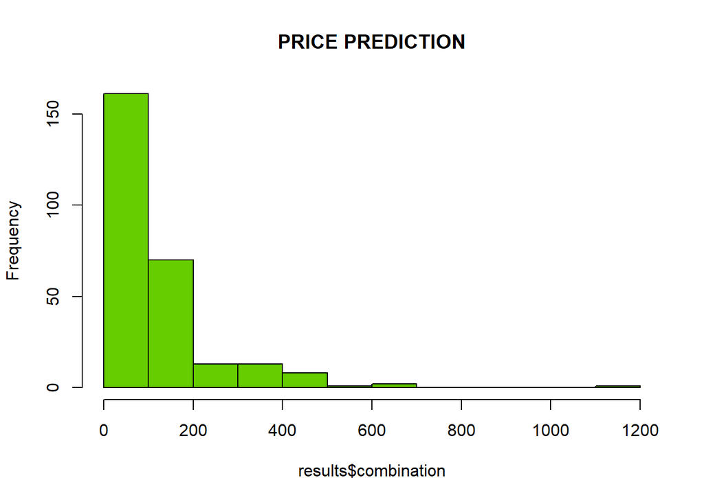

```r
hist(results$combination, col = "chartreuse3", main = "PRICE PREDICTION")
```

But lets see how are the errors distributed, the closest to zero, the better the model will have predicted, so:

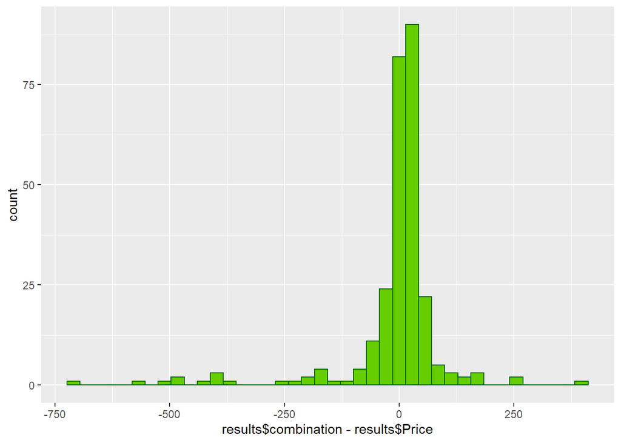

```r
ggplot()+aes(x = results$combination-results$Price)+geom_density(alpha = 0.1, color = "green")+geom_histogram(color = "darkgreen",
                                                                                                              fill = "chartreuse3", bins = 40)
```

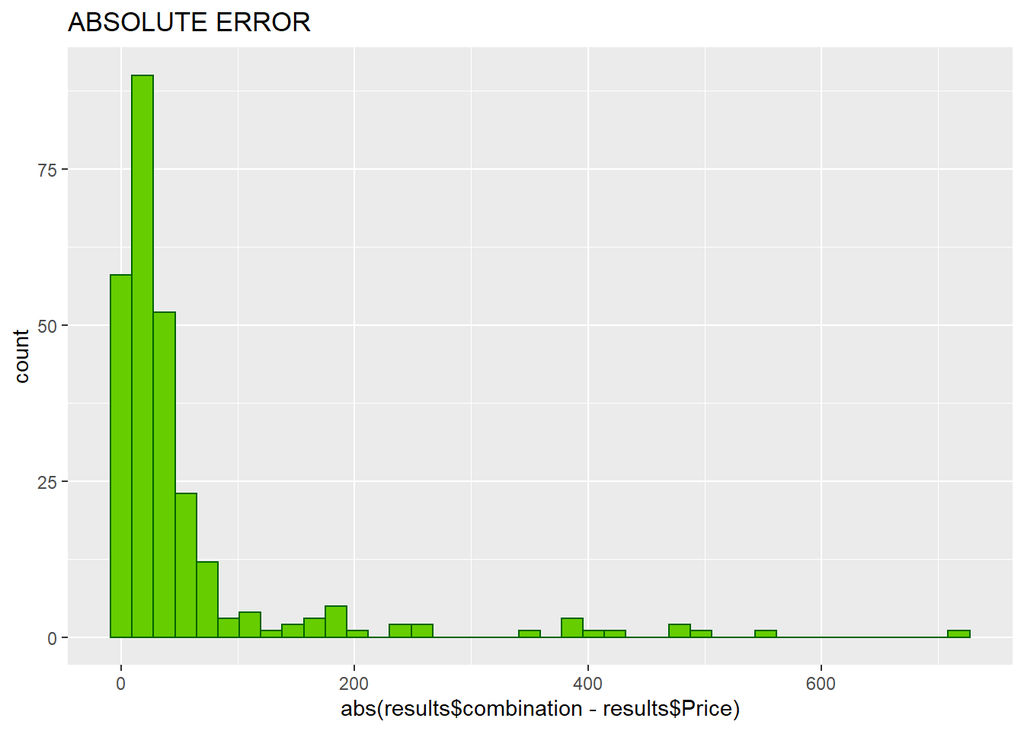

```r
#Better to plot the absolute value.
ggplot()+aes(x = abs(results$combination-results$Price))+geom_density(alpha = 0.1, color = "green")+geom_histogram(color = "darkgreen",
                                                                                                              fill = "chartreuse3", bins = 40)+
  labs(title = "ABSOLUTE ERROR")
```

It does not present such a huge error in predicting so it is good.

LETS see the noise in the variables:

```r
#set as noise
noise = (results$combination-results$Price)[0:100]

lower = results$combination[101:length(results$combination)] + quantile(noise,0.05, na.rm=T)
upper = results$combination[101:length(results$combination)] + quantile(noise,0.95, na.rm=T)

pred_final = data.frame(price = results$Price[101:length(results$Price)],
                        predictions = results$combination[101:length(results$Price)],
                        lower = lower,
                        upper = upper)
pred_final = pred_final %>% mutate(out = factor(ifelse(price<lower | price > upper,1,0)))

mean(pred_final$out==1)
```

```
## [1] 0.03550296
```

Really low percentage of observations are out of the 90% interval, so that are very good news.

Finally lets polot all the data that were inside and outside of this interval:

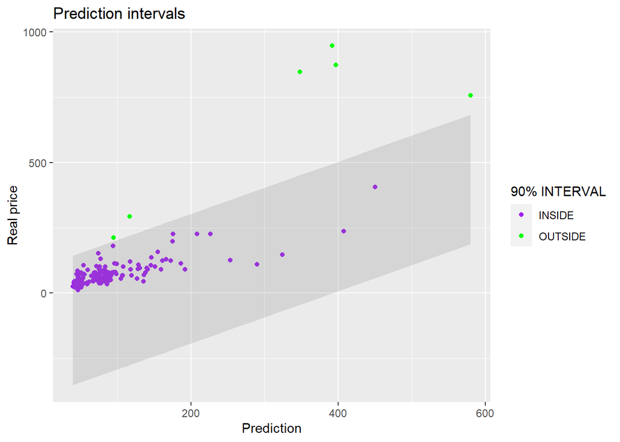

```r
ggplot(pred_final)+ aes(x=predictions, y=price)+
  geom_point(aes(color=out)) + geom_ribbon(aes(ymin=lower,ymax=upper),alpha=0.2, fill = "grey50") +
  labs(title = "Prediction intervals", x = "Prediction",y="Real price")+
  scale_color_discrete(type=c("purple","green"),labels = c("INSIDE","OUTSIDE"), name = "90% INTERVAL")
```

There can be appreciated very few data outside of the region, so the combination of the models, can be said that predicted more or less good the testing subset.

We could modify the area by changing the limits/percentage of the confidence interval. In another words, if we want to predict better the smartphones Prices. But i really think that a 90% interval is big enough.

# FINAL CONCLUSION

This project helped me to understand clearly the different algoritms that can be applied in each of the sections of the duty.

Classification part has been totally conditioned by the set of values I setted in the table as a company and somehow, some models did not perform that good in predicting since it was totally conditioned by the optimization of the “company” requirements. Moreover, the threshold was completely affected by that, so in some parts, results may have no sense. In spite of that, the models performed as it was expected.

Important to say that I found that benchmarks are really important to set an initial point from which you start computing models.

In the other side, Regression worked correctly and little by little, better models were achieved. It should be emphasised that the linear models produced over a 6% worse than machine learning algorithms.

Finally, the model combination predicted data really good in the 90% confidence interval.

# REFERENCIAS

- https://www.pluralsight.com/guides/linear-lasso-and-ridge-regression-with-r
- https://rpubs.com/arquez9512/599268
- https://stackoverflow.com/
- https://www.rdocumentation.org/
- https://www.statology.org/